# file names

# LL vs LMA using species by site means

Overall plot shows a lack of relationship when HATE included. This is because it has such a high LMA. The youngest and oldest plants have no pattern, presumably because LL data are inaccurate

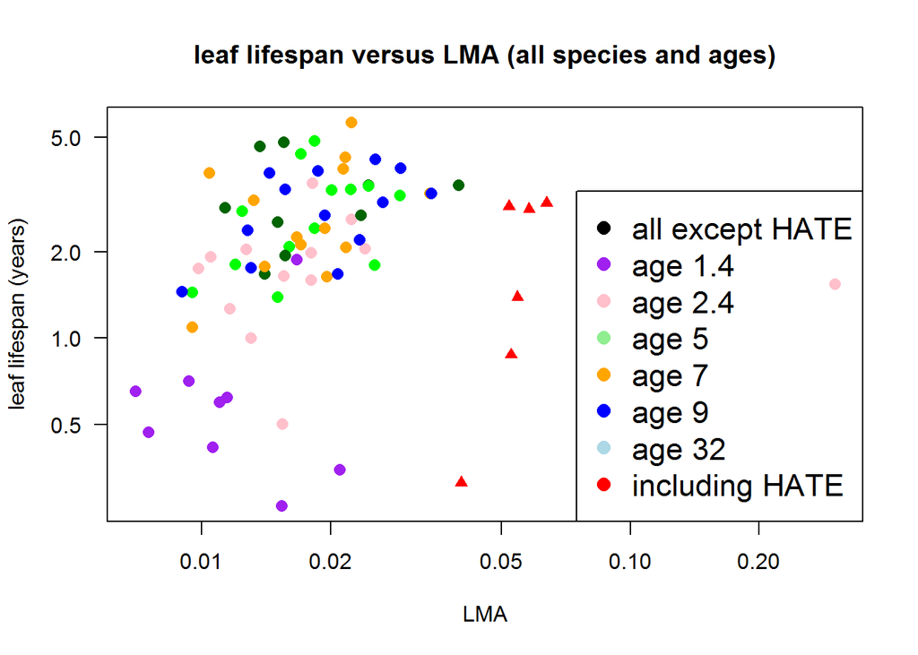

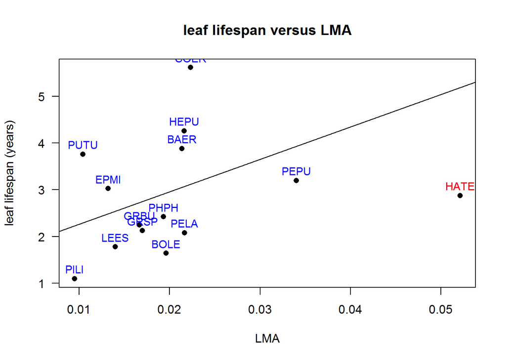

# Leaf lifespan patterns

First a model showing data by age and species, omitting the youngest plants. Uses calculations for “leaf births” only. Plots of leaf lifespan by age for each of the species

Age is not significant, but some significant interactions (COER, HATE, HEPU) And many species have sigificantly different LL from one another

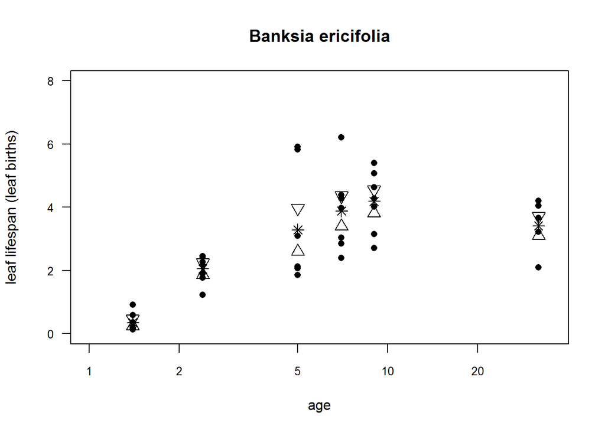

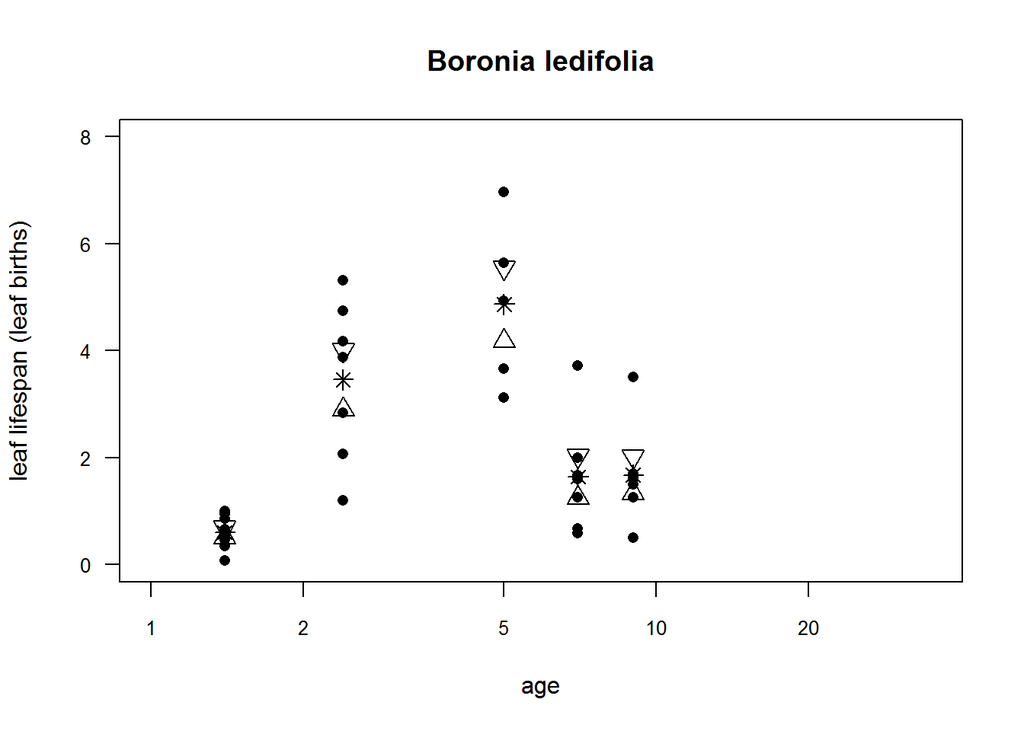

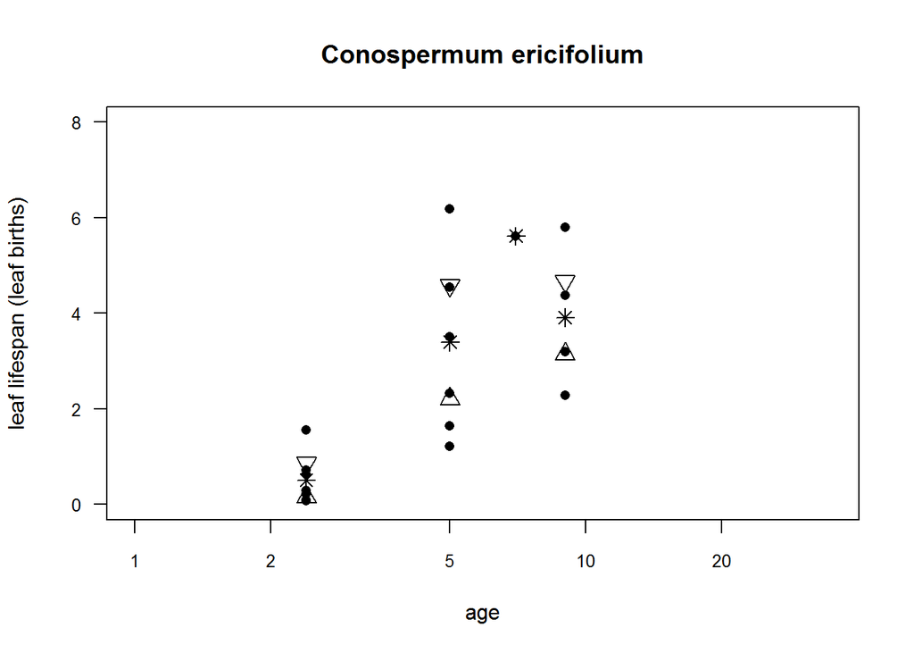

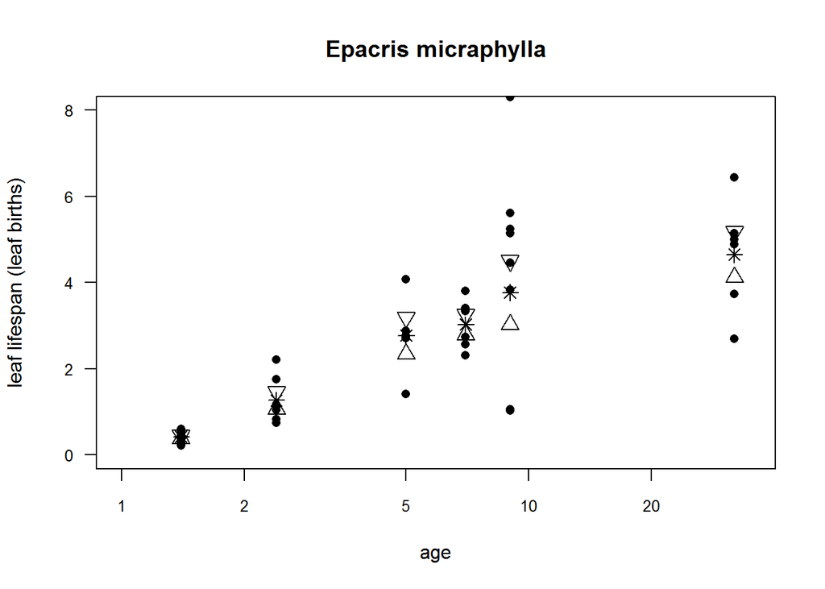

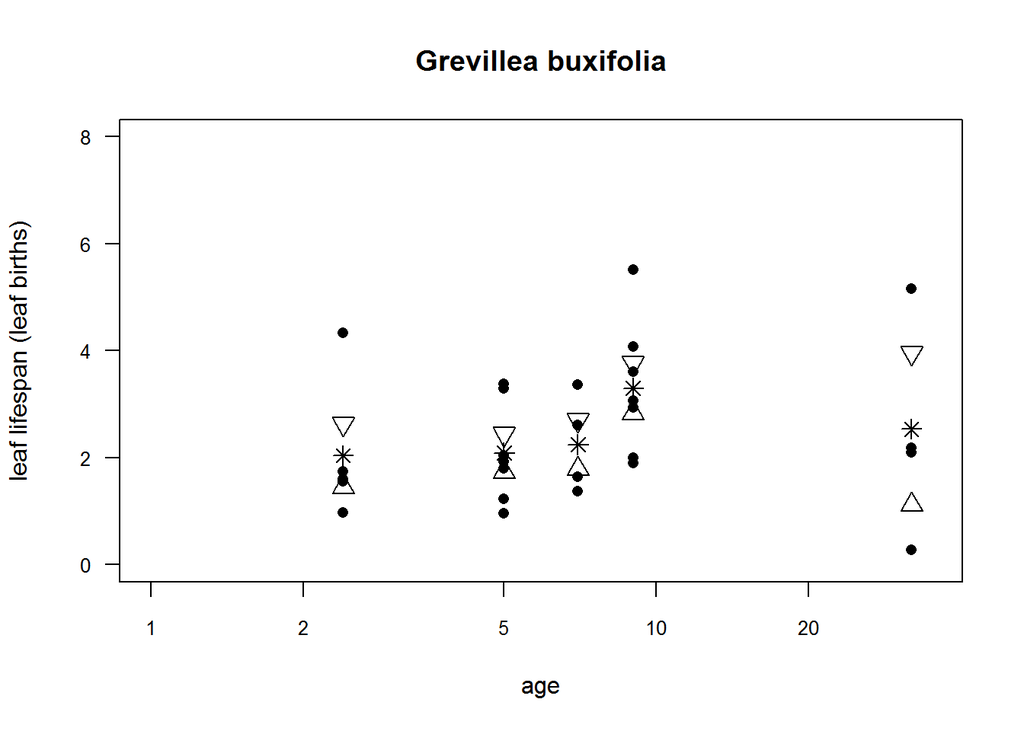

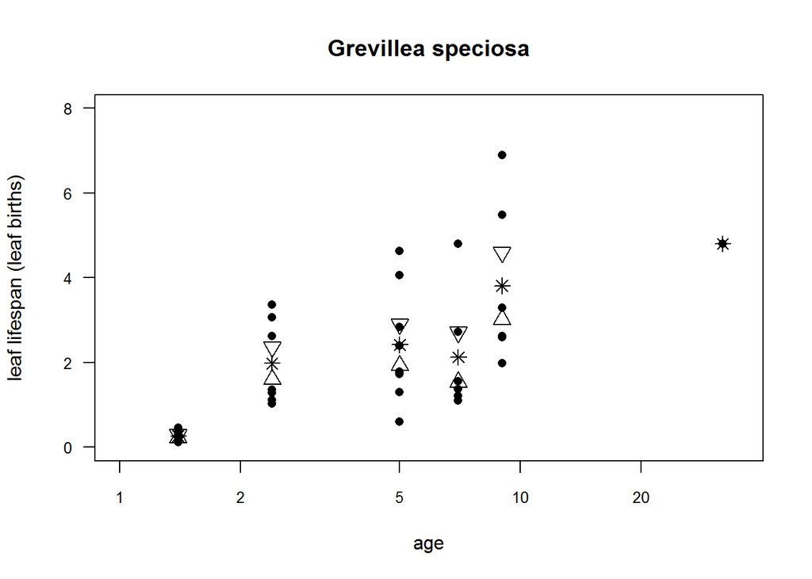

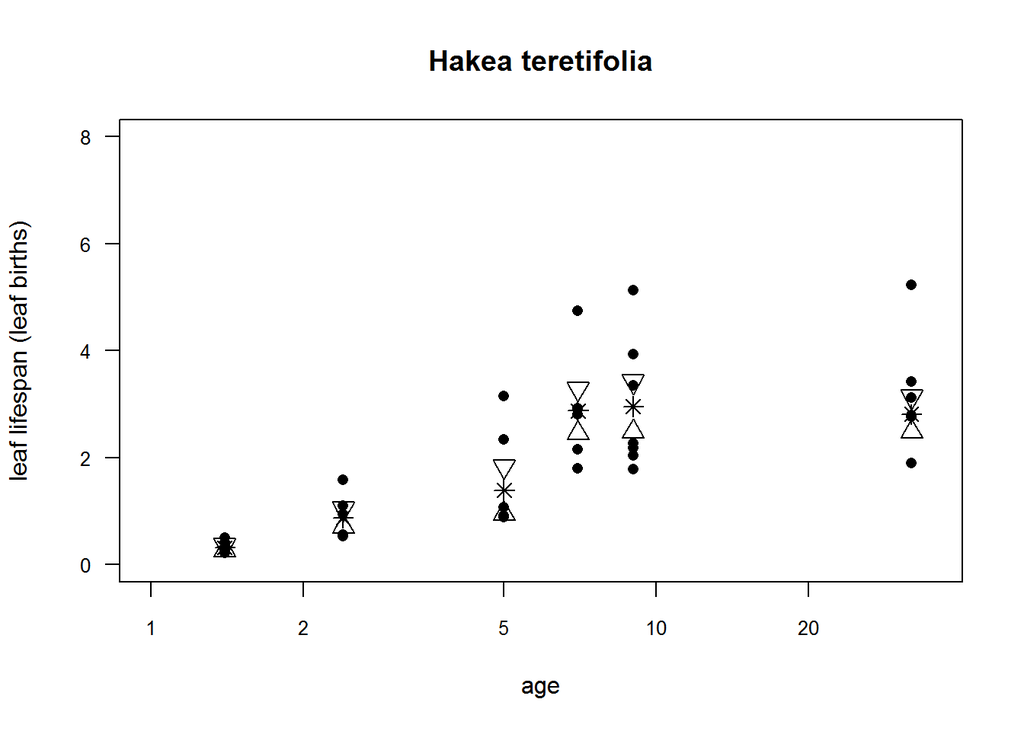

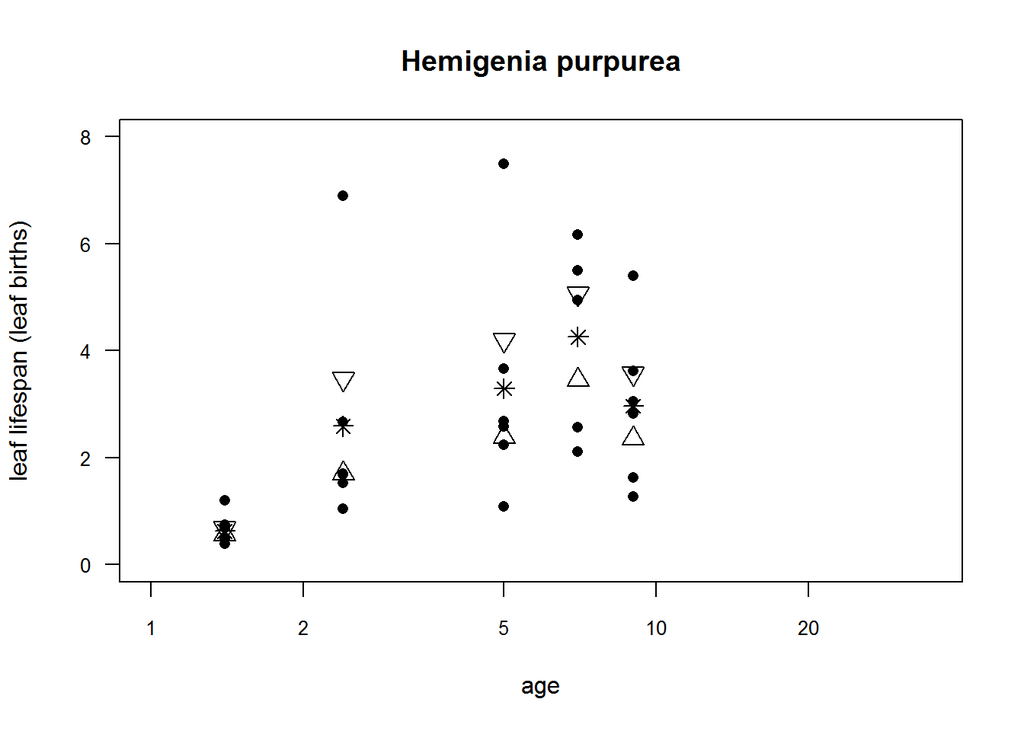

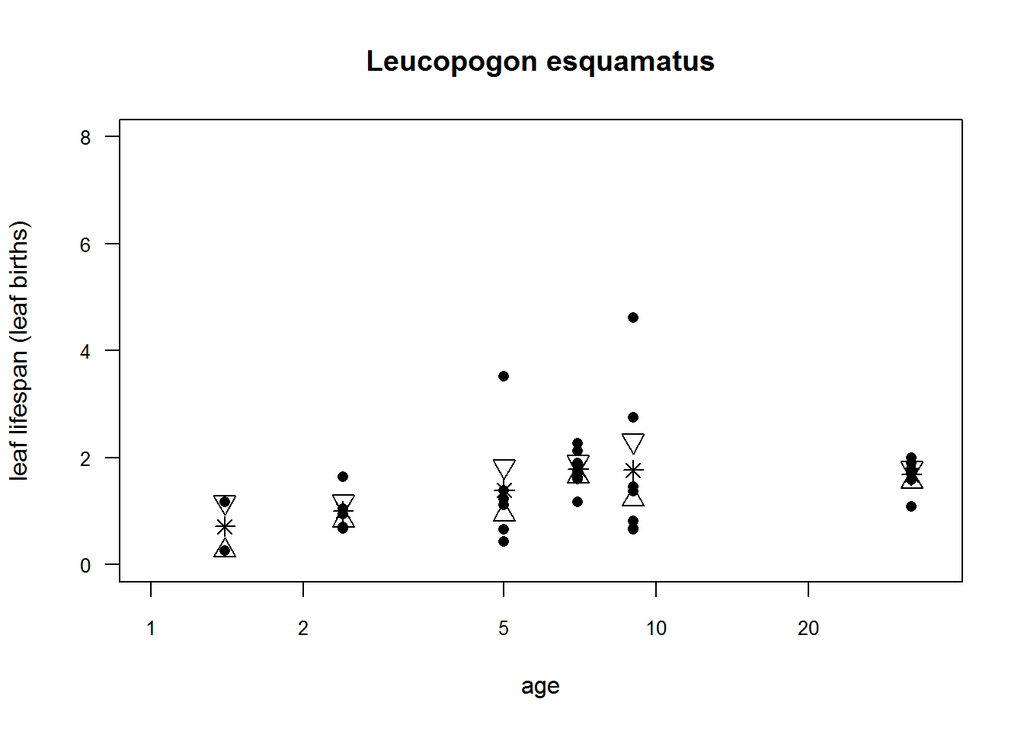

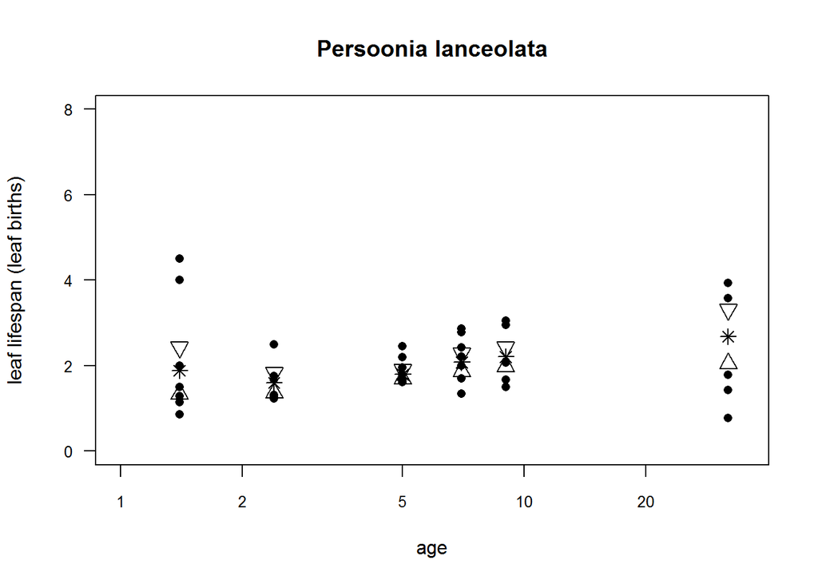

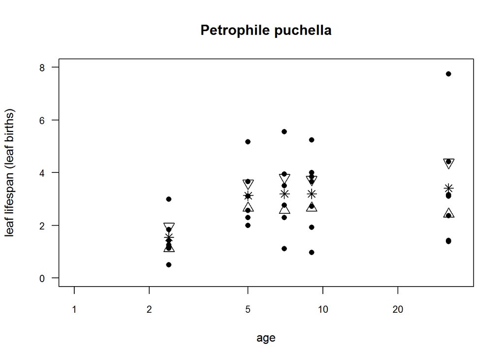

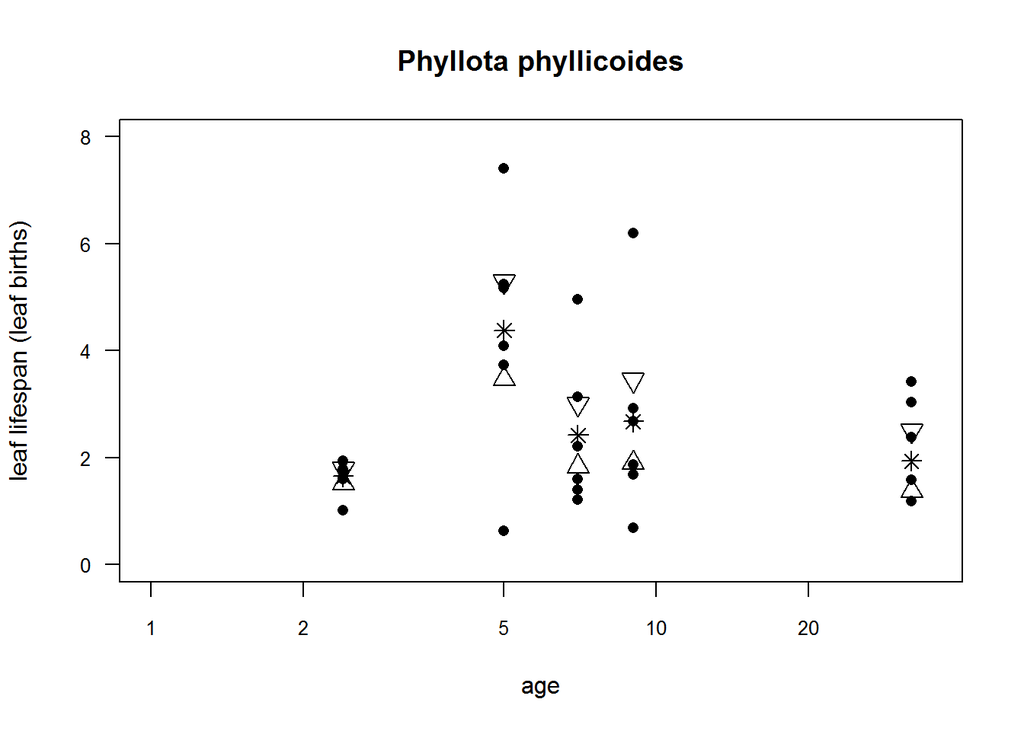

[2 more figures not shown]

# LMA by age, species, without youngest plants

There is also no overall affect of age on LMA, although a few species would show an effect if analyzed independently. (Again, this model omits 1-year old plants.)

```
## Source: local data frame [14 x 2]
##
##    species  mean(LMA)
## 1     BAER 0.02271667
## 2     BOLE 0.01658462
## 3     COER 0.02173333
## 4     EPMI 0.01263333
## 5     GRBU 0.01472222
## 6     GRSP 0.01723529
## 7     HATE 0.05438636
## 8     HEPU 0.02080667
## 9     LEES 0.01306250
## 10    PELA 0.02129412
## 11    PEPU 0.07544444
## 12    PHPH 0.01688235
## 13    PILI 0.00910000
## 14    PUTU 0.01062778
```

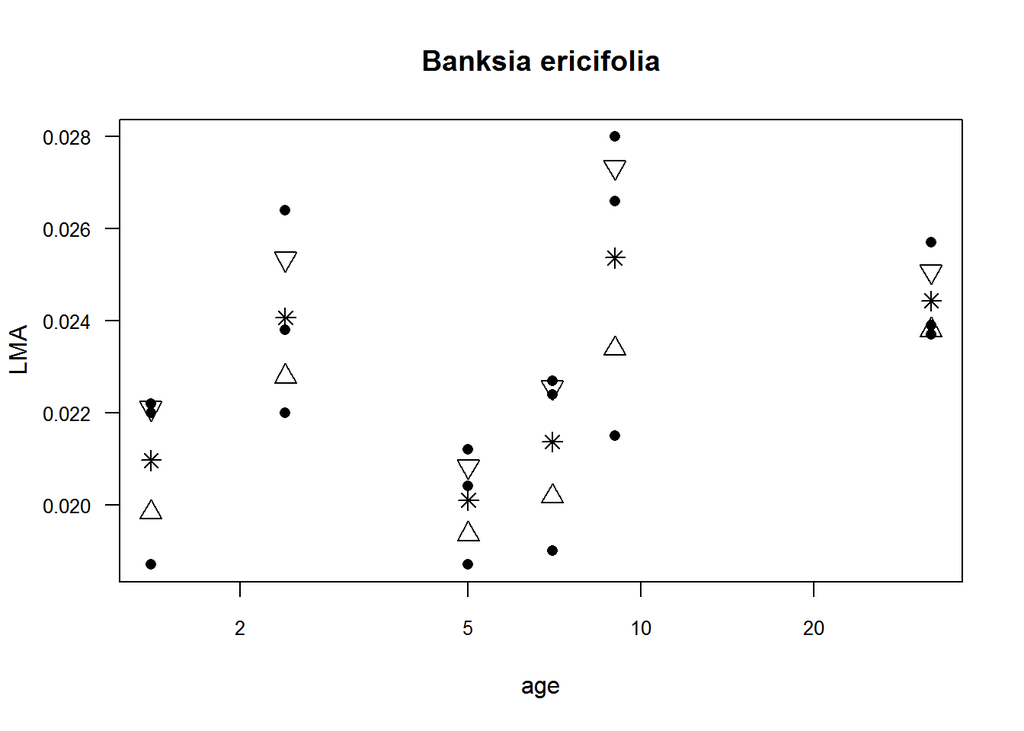

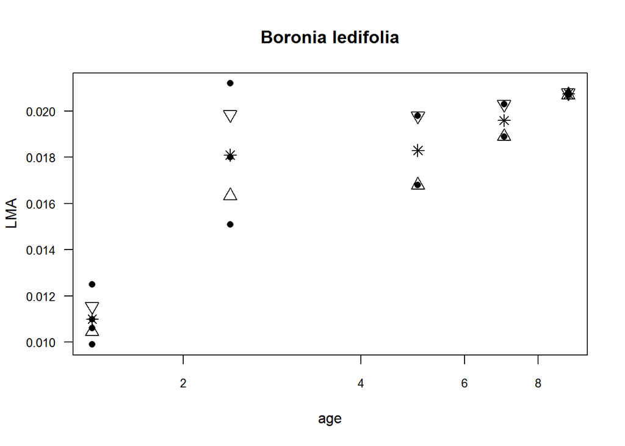

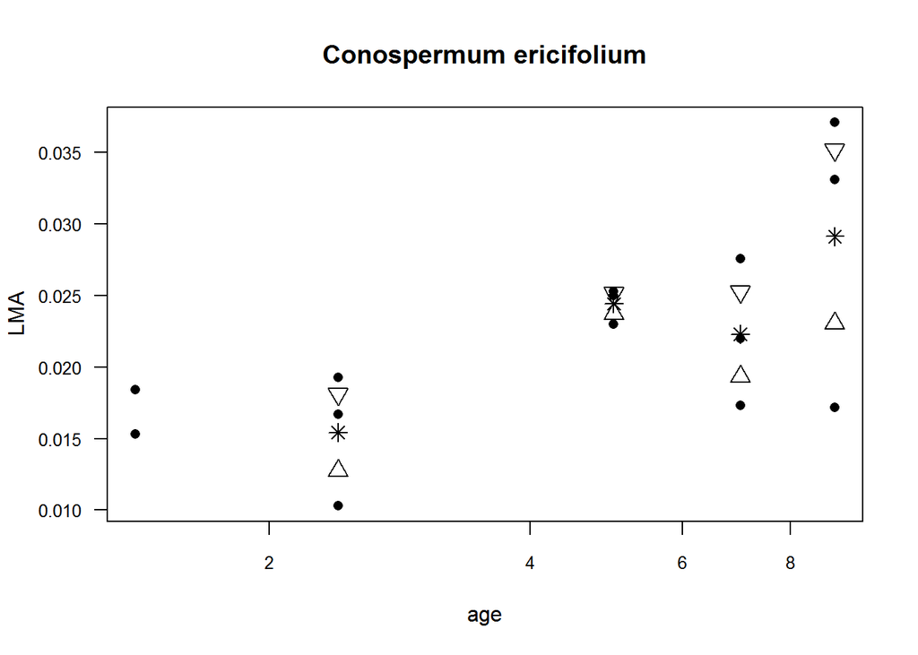

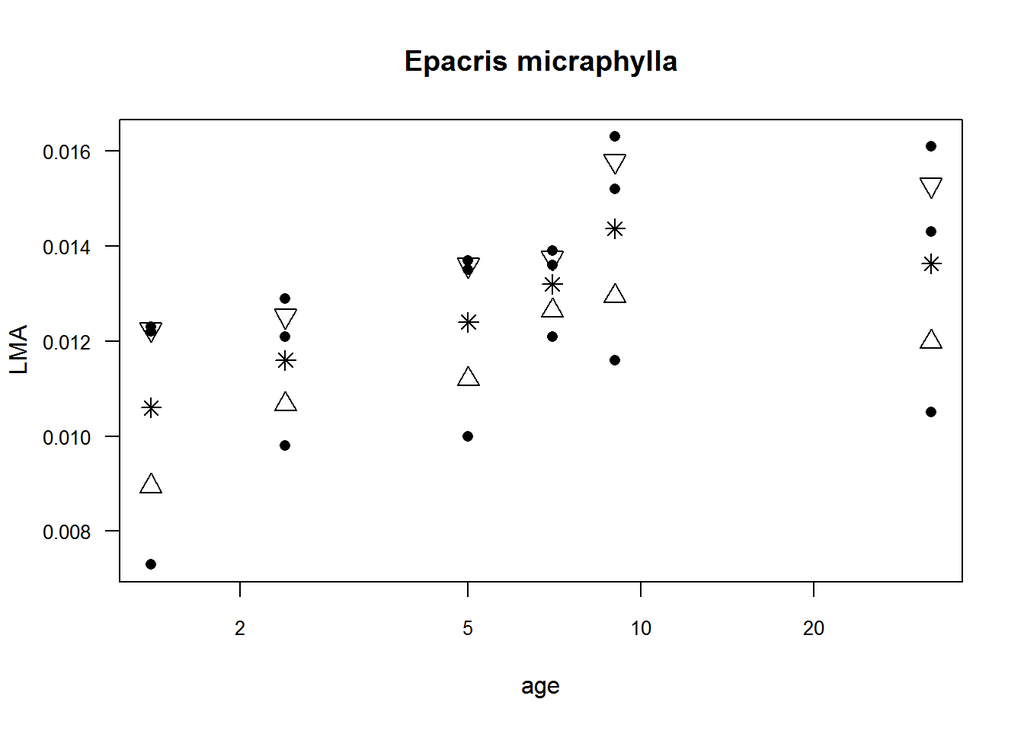

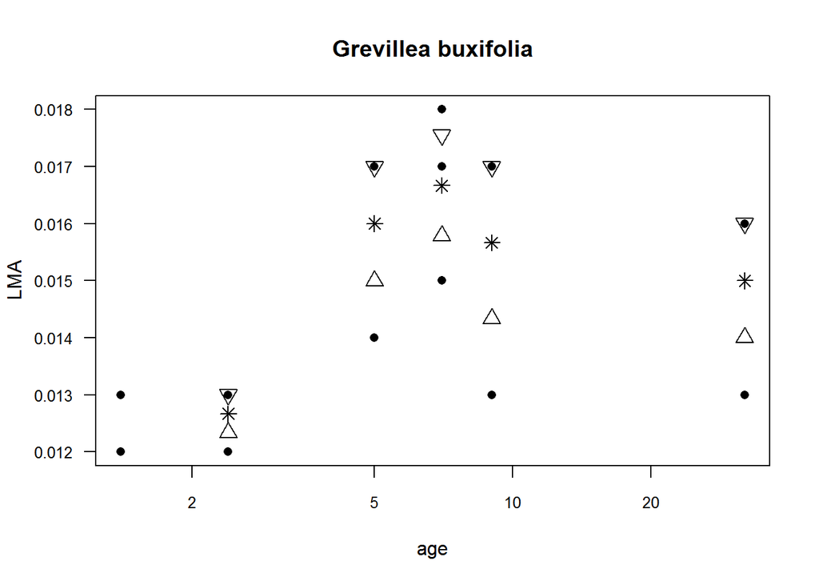

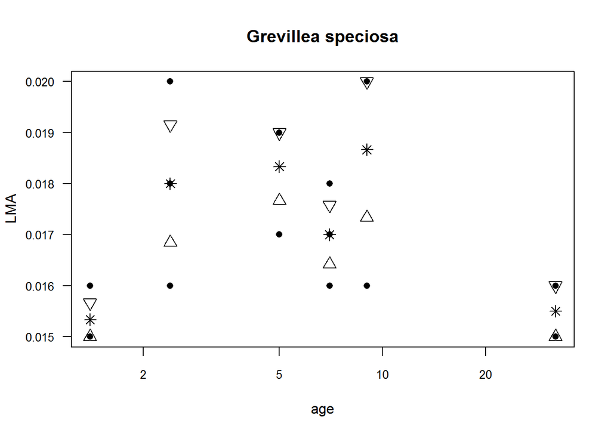

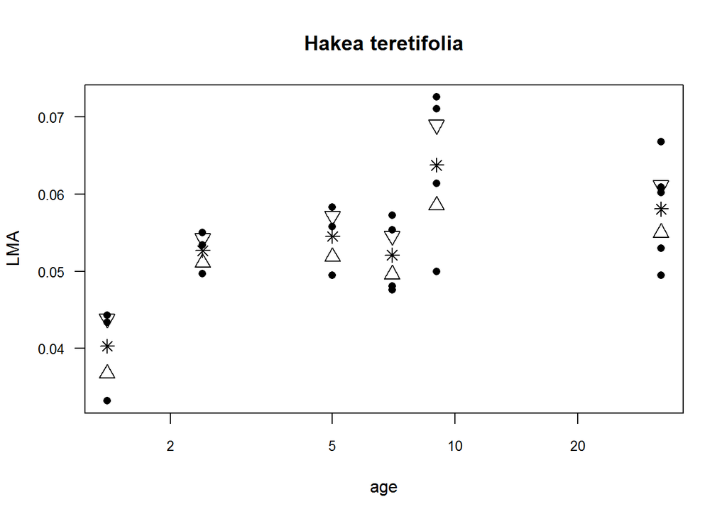

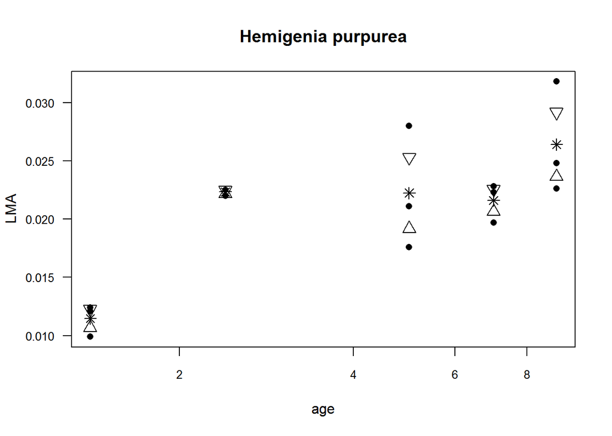

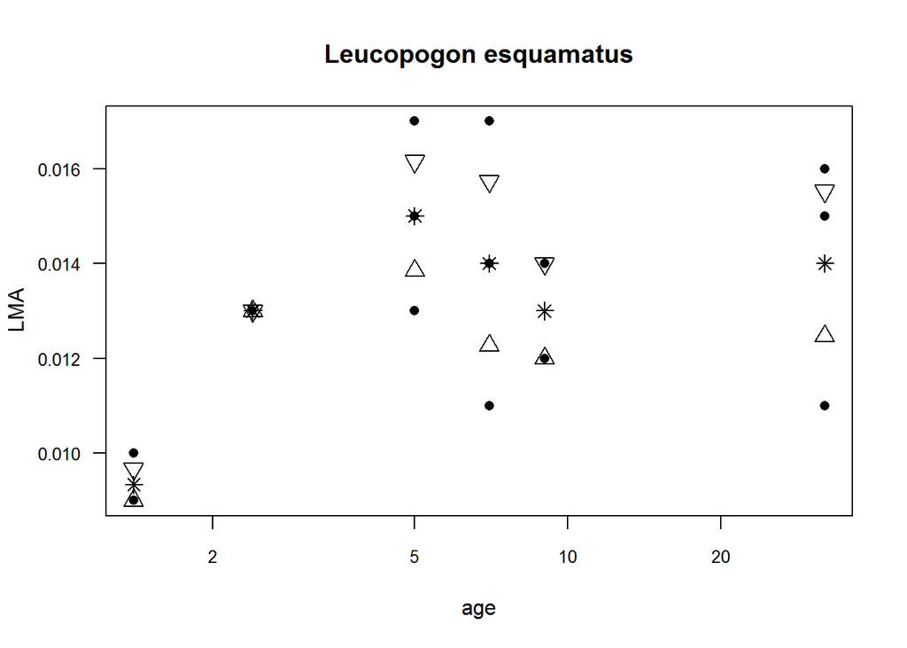

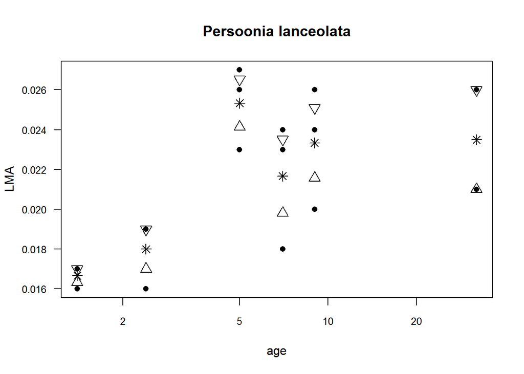

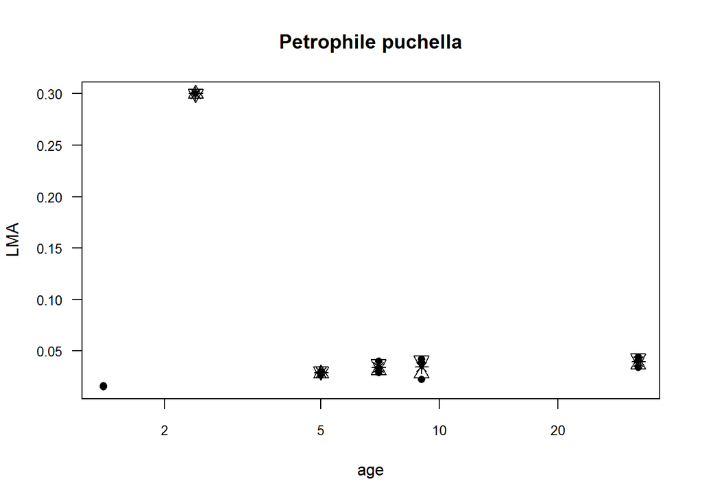

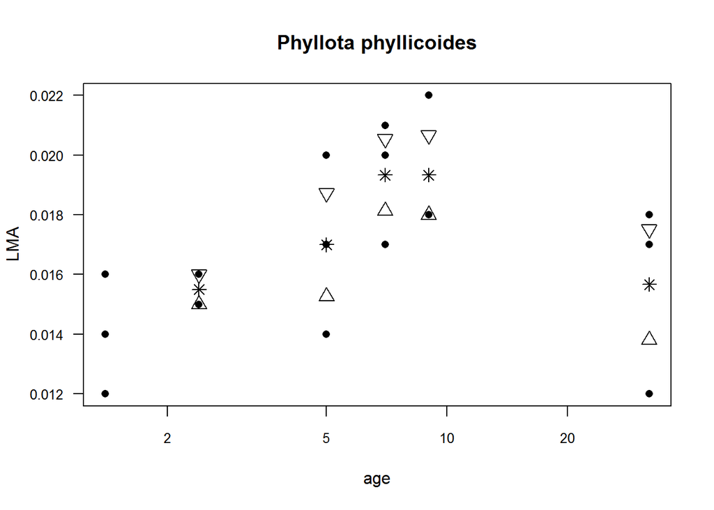

[2 more figures not shown]

# models with leaf counts per age

The number of leaves on a leader is slightly affected by age however, with a decrease in leaf count along the leader with increasing age. This is what gives the perception of fewer leaves in some older plants. I’m not sure why this pattern looks stronger than leaf lifespan.

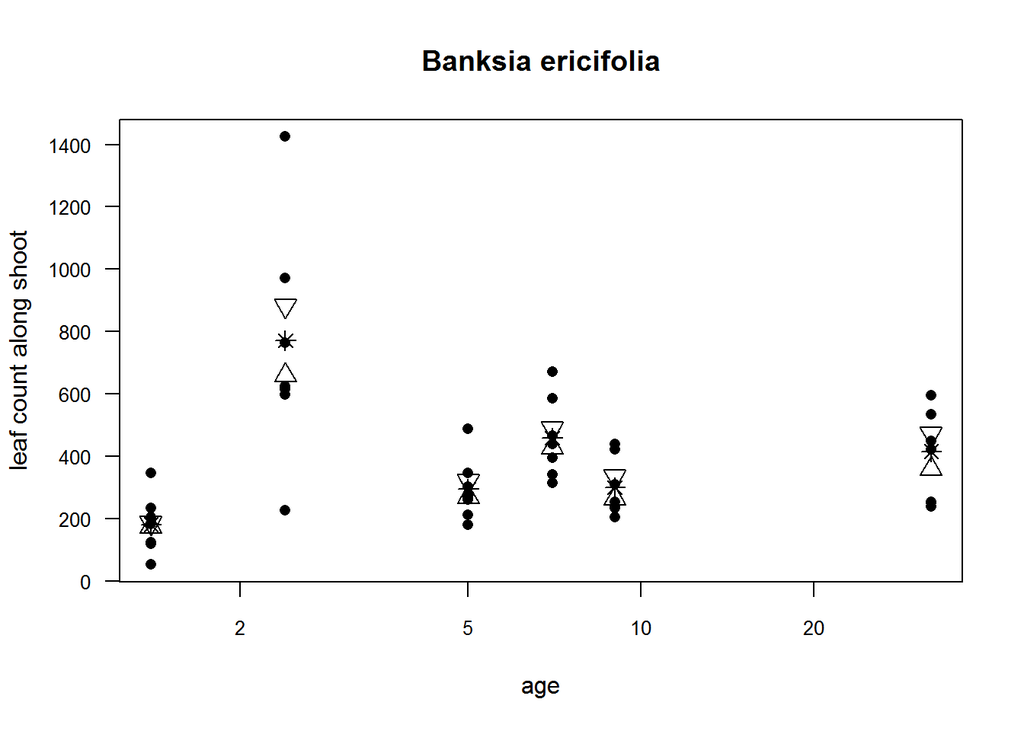

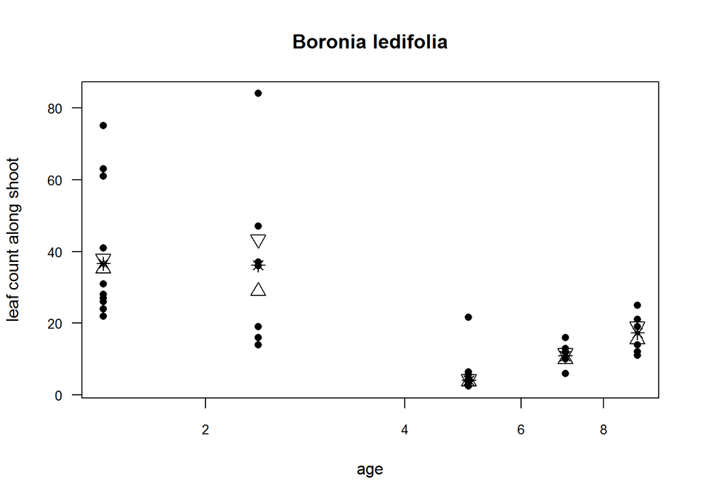

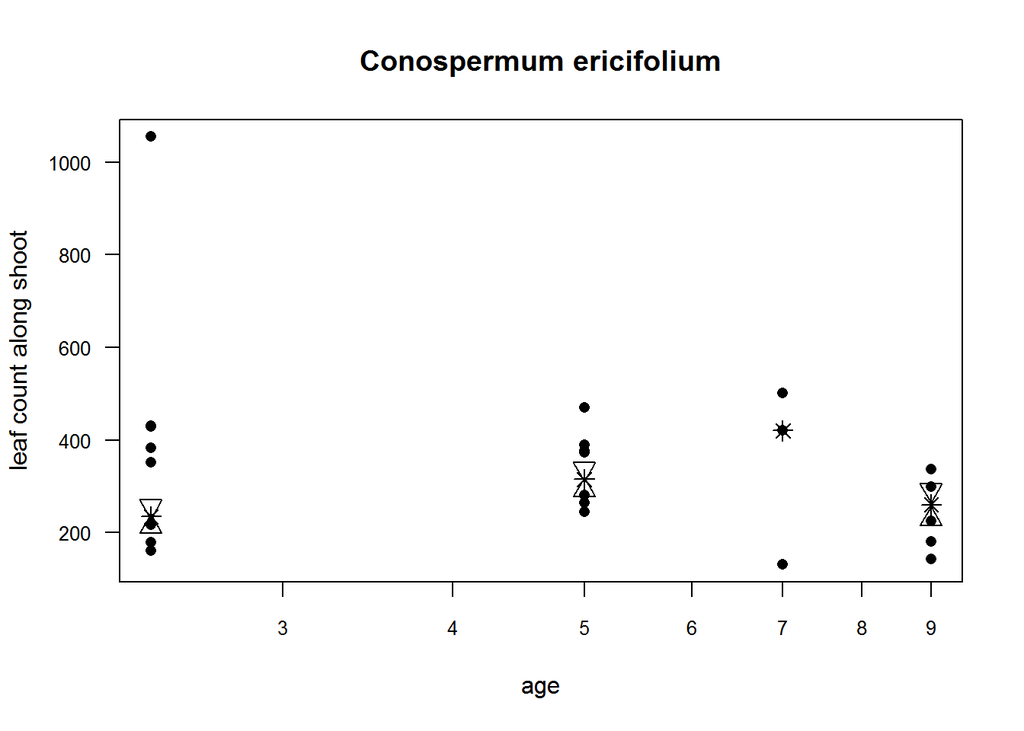

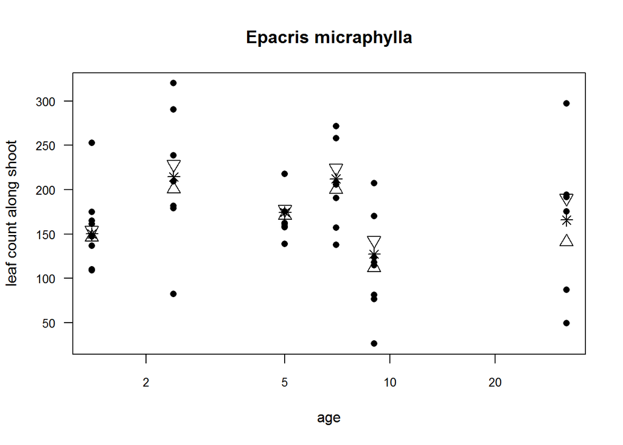